# Learn the Basics of AI

2021-01-07T00:00:00Z

**General introduction to machine learning**

A good place to start your journey into the basics of machine learning –the science of getting computers to act without being explicitly programmed– are the non-technical and easy to follow introductions to machine learning by Yufeng Guo from *Google’s AI Adventures* video-series:

[figure not shown]

[figure not shown]

**Overview about the different machine learning algorithms**

Vasily Zubarev provides a very casual introduction to machine learning using easy to understand language and real-world examples in his blog vas3k.

- [Machine Learning for Everyone](https://vas3k.com/blog/machine_learning/?ref=hn)

**Interactive visual example of a decision tree algorithm**

R2D3 is an experiment in expressing statistical thinking with interactive design and they provide an excellent visual introduction to machine learning:

- [Visual introduction to machine learning](http://www.r2d3.us/visual-intro-to-machine-learning-part-1/)

In this video, Google’s Laurence Moroney will guide you through the basic principles of machine learning (especially deep learning):

[figure not shown]

**Introduction to Recommender Systems**

CS50 is Harvard University’s introduction to the intellectual enterprises of computer science and the art of programming. They provide an easy to follow introduction to recommender systems:

[figure not shown]

**Overview about crucial machine learning content**

[figure not shown]

- [Google’s Machine Learning Crash Course](https://developers.google.com/machine-learning/crash-course/)

Google recently published a series of internal AI training resources originally developed for its engineers. The *crash course* provides a fast-paced and practical overview about the fundamental concepts of machine learning. Here you can learn and apply fundamental machine learning concepts, get real-world examples with the companion [Kaggle competition](https://www.kaggle.com), or visit [Learn with Google AI](https://ai.google/education/) to explore the full library of training resources.

**Introduction to Neural Networks**

Excellent introduction to neural networks created by Grant Sanderson.

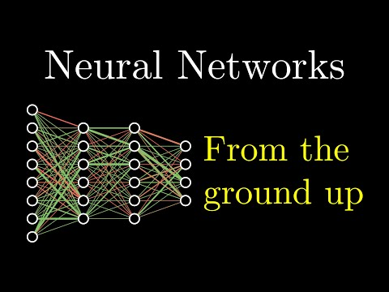

Advanced material:

**Detailed machine learning course with code development**

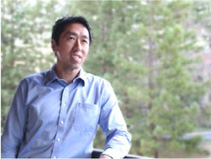

- [Introduction to Machine Learning](https://www.coursera.org/learn/machine-learning) from Andrew Ng

In this excellent course from Andrew Ng, you will learn about the most effective machine learning techniques, and gain practice implementing them and getting them to work for yourself.

This course provides a broad introduction to machine learning, datamining, and statistical pattern recognition. Topics include:

- 1. Supervised learning (parametric/non-parametric algorithms, support vector machines, kernels, neural networks).
- 2. Unsupervised learning (clustering, dimensionality reduction, recommender systems, deep learning).
- 3. Best practices in machine learning (bias/variance theory; innovation process in machine learning and AI).